# The celestial sphere II

This is the second of two related packets. The packets together cover the following topics:

- Coordinate systems
  - latitude and longitude
  - horizontal coordinate system: altitude and elevation
  - equatorial coordinate system: declination and right ascension
- Celestial motion
  - ecliptic
  - equinoxes and solstices
  - rotation and revolution
- Measurement
  - sextant
  - anatomical features
  - constellations and asterisms

## Equatorial coordinate system

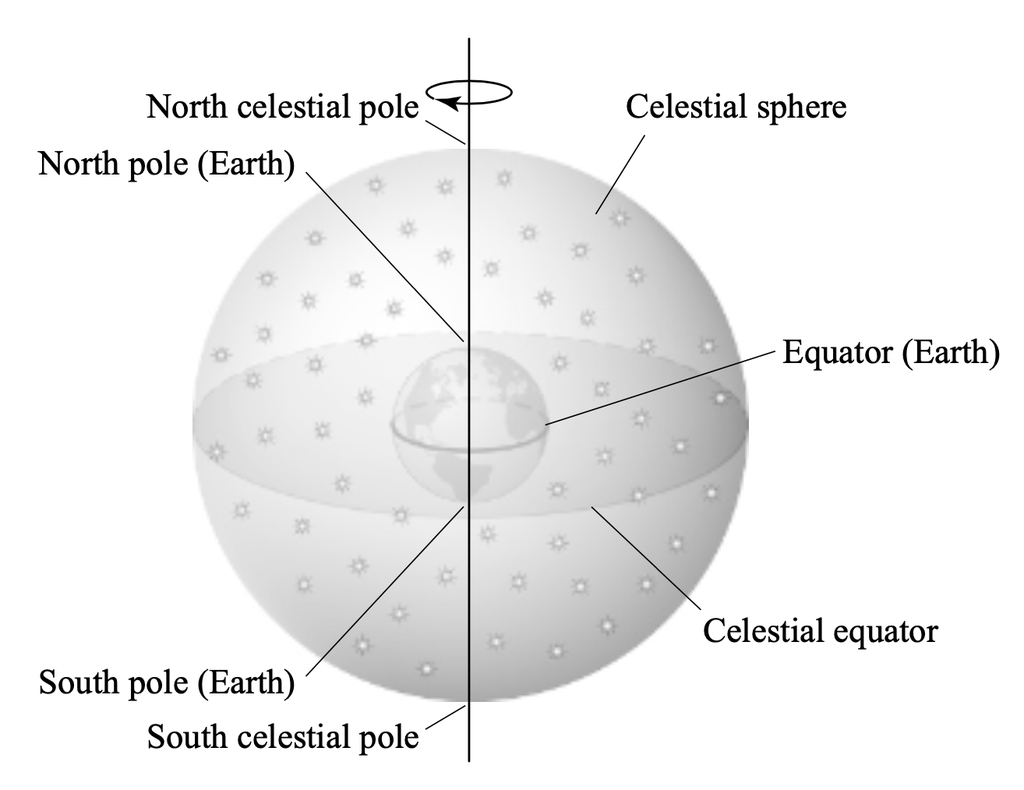

Now suppose you want to tell a classmate where in the sky to look for that astronomical object the following evening. That object may still be at or near the same point in the sky, but your friend’s position on Earth may not match yours, and anyway the position of Earth has changed in the meantime. To overcome these significant hurdles, we need another coordinate system that does not change relative to the fixed stars, or at least changes only in a way that is corrected relatively easily. A system of this type is the [equatorial coordinate system](https://en.wikipedia.org/wiki/Equatorial_coordinate_system). In this system, the Earth is surrounded by the celestial sphere with the fundamental plane passing through Earth’s equator. This plane intersects the celestial sphere in the **celestial equator** (the red circle in the figure below). The coordinate of latitude in degrees above the great circle is called the **declination** (DEC). It is denoted by the lower-case Greek letter delta $\delta$ (or just DEC) and it runs from $- 90{^\circ}$ below the equator to $+ 90{^\circ}$ above.

To fix a coordinate of longitude, we need the analog of the prime meridian. To define it, we need to first discuss the apparent motion of the Sun in the sky. During the day, the Sun rises in the East and sets in the West, but where exactly those points are relative to due East/West depends on the time of year. During the summers in the northern hemisphere, the Sun rises and sets north of the cardinal directions and during the winter it does so south of them. Because of this, there are two days a year when the Sun rises due East and sets due West called the **equinoxes**.

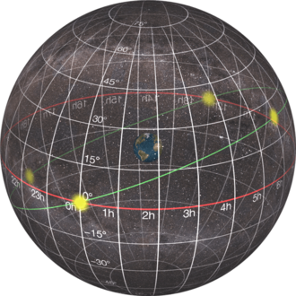

There are also two days at which the Sun rises and sets as far away from the due East/West as possible. During these days the sun reaches either the highest point in the sky (summer) or the lowest point in the sky (winter) for that year. These days are called the **summer solstice** and **winter solstice**, respectively.

### Problem 1

> In this problem you will use this [simulator](https://astro.unl.edu/naap/motion3/animations/sunmotions.html) to become familiar with the motion of the sun in the sky. (You may be surprised to realize that it isn’t all that intuitive and straightforward.)
> 1. Find the dates for
>    1. the vernal equinox,
>    2. the summer solstice,
>    3. the autumnal equinox,
>    4. the winter solstice.
> 2. Find the sun’s maximum/minimum declination, and compare the dates at which they occur with your answers in part a.
> 3. Locate the radio button labeled “Show the **ecliptic**” and toggle it on and off. Play around with the simulator until you understand the meaning of this great circle.
> 4. Locate the radio button labeled “Show analemma” and select it. Play with the settings until you figure out what it is. Confirm your answer using the “Step by day” animation mode.
> 5. The word *equinox* is Latin for “equal night” and *solstice* comes from the Latin for “solar stand-still”. From your work, explain why these days are so named. In other words, what is true of the lengths of the days/nights and the height of the sun on these days?

In this problem, you should have discovered that the ecliptic is defined to be the apparent path the Sun traces out across the celestial sphere in one year. This path is tilted relative to the celestial equator at an angle of $23.4{^\circ}$, and it intersects it at antipodal points corresponding to the position of the sun during the equinoxes.

Returning now to our equatorial coordinate system, we define the **primary direction** to be *the direction from Earth to the vernal equinox* (labeled ♈ (Aries) in the figure at right). Starting from this direction, we define a coordinate increasing in the couner-clockwise direction when viewed from the north. This coordinate is called **right ascension** (RA) and is denoted by the Greek letter $\alpha$ (or just RA). It is defined to run from 0 hours to 24 hours with angles further subdivided into minutes (and seconds, *etc*. if needed).

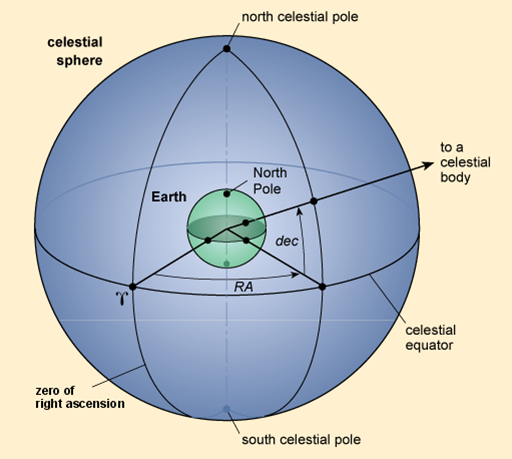

### Problem 2

> In this problem, we begin to consider how to translate between horizontal and equatorial coordinate systems.
> 1. Explain in words the difference between the altitude of the sun, its declination, and what these have to do with the observer’s latitude.
> 2. Go back to the solar motion [simulator](https://ccnmtl.github.io/astro-simulations/sun-motion-simulator/) and figure out the relationship between the latitude $\phi$ of the observer, the declination $\delta$ of the Sun, and the altitude $\alpha$ of the Sun *at noon*. You should put your relation in the form of an equation relating these three quantities.
> 3. The geographical coordinates of TJ are $38{^\circ}49'06''$ north latitude and $77{^\circ}10'07''$ west longitude. What is the altitude of the sun at noon during the
>    1. summer solstice?
>    2. winter solstice?

There are online calculators you can use to convert between the two (cf. *e.g.* [here](https://clearskytonight.com/projects/astronomycalculator/coordinate/ecliptic_equatorial.html)), but this conversion is not usually needed for amateur astronomy. Instead, it is more useful to learn to locate the origin of coordinates in the night sky, and then refer to that whenever you are looking for a specific astronomical object.

### Problem 3

> Find a star chart from the lab and use it to locate the origin of the equatorial coordinate system. Identify the nearest **asterism**. In which **constellation** is it?

### Problem 4

> Use this [night sky mapping tool](https://in-the-sky.org/skymap2.php) to investigate the differences between the equatorial and horizontal coordinate systems.
> 1. Play with the date and time until you are convinced that you are looking at the sun rising on the vernal equinox.
> 2. What are the declination and right ascension of the sun at this time?
> 3. Jump forward in time and observe the motion of the origin of the coordinates of the equatorial coordinate system.
> 4. Turn on the RA/Dec grid and describe what you see. Do the lines of constant declination do what you expect? Where do the lines of constant right ascension converge?
> 5. Mouse over Polaris and move the cursor in a tiny circle around the star. Describe what is happening with the declination coordinate. What about the RA coordinate?
> 6. Turn on the Alt/Az grid and describe what you see.

As this exercise demonstrates, it is useful to refer to objects in the sky relative to other recognizable objects. Certain combinations of stars have been decreed since antiquity to form **constellations**. There are 88 constellations total, of which 12 are intersected by the ecliptic. These distinguished combinations make up the **zodiac**.

### Problem 5

> Collect two star charts from the back of the room. (You will need one for each the northern and southern hemisphere.) Using a star chart, write down the 12 constellations of the zodiac in the order that the sun passes them on its way around the ecliptic, starting at the vernal equinox.

### Problem 6

> On your charts mark
> 1. Polaris at 02h 31m 49s RA and +89° 15′ 51″ dec.
> 2. the center of our Galaxy, called [Sagittarius A](https://en.wikipedia.org/wiki/Sagittarius_A), located at 17h 45m 40s RA and −29° 0′ 28″ declination.
> 3. [Messier 87](https://en.wikipedia.org/wiki/Messier_87) located at 12h 30m 49s RA and +12° 23′ 28′′ DEC.
> 4. Sirius at 06h 45m 09s RA and −16° 42′ 58″ DEC.
> 5. [Betelguese](https://en.wikipedia.org/wiki/Betelgeuse) (05h 55m 10s RA and +07° 24′ 25″ dec.) and Rigel (05h 14m 32.s RA and −08° 12′ 06″ DEC.)
> 6. Messier 31 (a.k.a. [Andromeda galaxy](https://en.wikipedia.org/wiki/Andromeda_Galaxy)) is at 00h 42m 44s RA and +41° 16′ 9″ DEC.

### Problem 7

> Go out into the night and single out three astronomical bodies that you can see. Write down the time and date and your latitude and longitude (which you may look up). For each of the three
> 1. Write a name you will use to refer to it.
> 2. Estimate its altitude and azimuth and make note of these.
> 3. Find it on your star chart and estimate its right ascension and declination.
> 4. Using this [website](https://in-the-sky.org/), work out your best guess for the identity of your object.